# act_report

## Report: act_report

The insights and visualization(s) produced from my wrangled data.

The dataset that was wrangled (and analyzed and visualised) is the tweet archive of Twitter user @dog_rates, also known as WeRateDogs. WeRateDogs is a Twitter account that rates people's dogs with a humorous comment about the dog. These ratings almost always have a denominator of 10. The numerators, though? Almost always greater than 10. 11/10, 12/10, 13/10, etc. Why? Because "they're good dogs Brent." WeRateDogs has over 4 million followers and has received international media coverage.

After I gathered, assessed, cleaned and stored the data to the name twitter_archive_master.csv, it was then analysed.

Insights and visulizations produced include:

#### A. Plot a graph to evaluate tweets trend

#### B. Dog breed with the maximum and minimum retweet count

#### C. Plot a scatter plot graph to visualize the relationship between retweet_count and favorite_count

#### D. The most commonly used dog_stage

### Insights:

1. Tweets with less retweet count and favorite count are more than Tweets with high retweet count
2. favorite tweets has the highest tweet counts(People likes tweet more than they retweet a tweet)
3. As the number of tweet retweeted increases, so also the number of favorite tweets.
4. Labrador Retriever has the maximum retweet count with the prediction confident of 0.8 and a rating of 13
5. The dog breed(English Setter) with the lowest retweet count has a low prediction score of 0.3 and a rating of 11
6. There is strong positive correlation between retweet count and favorite count.
7. The most common dog stage is pupper while the least common is floofer

### Visualization

#### A. Plot a graph to evaluate tweets trend

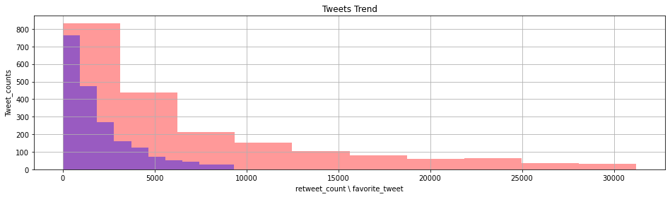

```python
percentile = twit_arch_clean.describe([0.95])
fav_cap = percentile['favorite_count']['95%']

ret_cap = percentile['retweet_count']['95%']

def popularity(twit_arch_clean, retweet_count, favorite_count):

    plt.figure(figsize=[16,4])
    data = twit_arch_clean['favorite_count'][twit_arch_clean['favorite_count'] < fav_cap]
    data_two = twit_arch_clean['retweet_count'][twit_arch_clean['retweet_count'] < ret_cap]
    data.hist(alpha = .4, bins = 10, color = 'red', range = [0, fav_cap])
    data_two.hist(alpha = .4, bins = 10, color = 'blue', range = [0, ret_cap])

    plt.title("Tweets Trend")
    plt.xlabel("retweet_count \ favorite_tweet")
    plt.ylabel("Tweet_counts")
popularity(twit_arch_clean, 'retweet_count', 'favorite_count')
```

- Tweets with less retweet count and favorite count are more than Tweets with high retweet count
- favorite tweets has the highest tweet counts(People likes tweet more than they retweet a tweet)
- As the number of tweet retweeted increases, so also the number of favorite tweets.

#### B. Dog breed with the maximum and minimum retweet_count

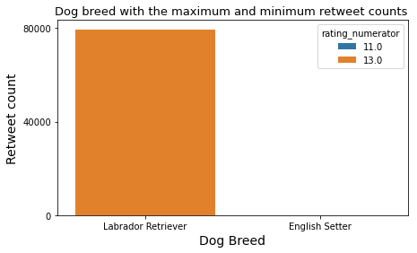

```python
plt.figure(figsize=(7,4))
#bargraph that shows the max and min retweet_count
sns.barplot(y="retweet_count", x="dog_breed", data=ret_data, hue="rating_numerator", dodge=False)
plt.xlabel('Dog Breed', fontsize=14)
plt.ylabel('Retweet count', fontsize=14)
plt.title('Dog breed with the maximum and minimum retweet counts ', fontsize=13)

plt.yticks([0,40000,80000]);
plt.show()
```

Let see if they are dogs

```python
ret_data
```

|  | tweet_id | timestamp | source | text | expanded_urls | rating_numerator | rating_denominator | name | dog_stage | jpg_url | dog_breed | prediction_confi | retweet_count | favorite_count |
| --- | --- | --- | --- | --- | --- | --- | --- | --- | --- | --- | --- | --- | --- | --- |
| 1005 | 744234799360020481 | 2016-06-18 18:26:18+00:00 | <a href="http://twitter.com/download/iphone" rel="nofollow">Twitter for iPhone</a> | Here's a doggo realizing you can stand in a pool. | https://twitter.com/dog_rates/status/744234799360020481/video/1 | 13.0 | 10 | NaN | doggo | https://pbs.twimg.com/ext_tw_video_thumb/744234667679821824/pu/img/1GaWmtJtdqzZV7jy.jpg | Labrador Retriever | 0.825333 | 79515 | 131075 |
| 2280 | 666102155909144576 | 2015-11-16 03:55:04+00:00 | <a href="http://twitter.com/download/iphone" rel="nofollow">Twitter for iPhone</a> | Oh my. Here you are seeing an Adobe Setter giving birth to twins!!! The world is an amazing place. | https://twitter.com/dog_rates/status/666102155909144576/photo/1 | 11.0 | 10 | NaN | NaN | https://pbs.twimg.com/media/CT54YGiWUAEZnoK.jpg | English Setter | 0.298617 | 16 | 81 |

```python
# image of the dog breed with the highest retweet_count(79515)
Image('https://pbs.twimg.com/ext_tw_video_thumb/744234667679821824/pu/img/1GaWmtJtdqzZV7jy.jpg')
```

[figure not shown]

```python
 # image of the dog breed with the lowest retweet_count(16)
Image('https://pbs.twimg.com/media/CT54YGiWUAEZnoK.jpg')
```

[output not shown]

- Labrador Retriever has the maximum retweet count with the prediction confident of 0.8 and a rating of 13
- The dog breed(English Setter) with the lowest retweet count has a low prediction score 0.3 and a rating of 11

  (Both dog have no name)

#### C. Plot a scatter plot graph to visualize the relationship between retweet_count and favorite_count

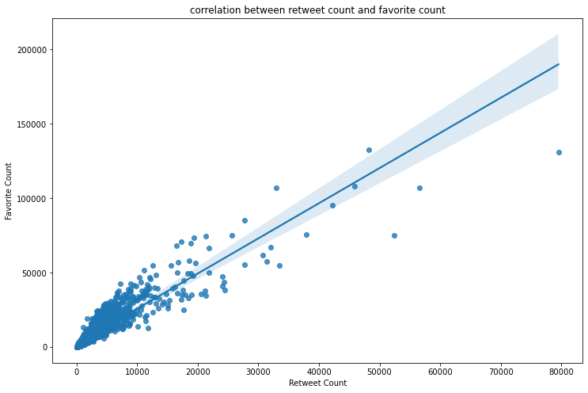

- There is strong positive correlation between retweet count and favorite count.

#### D. The most commonly used dog_stage

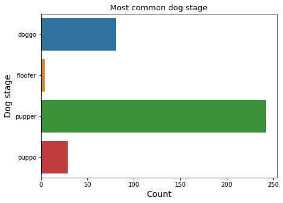

- The most common dog stage is pupper while the least common is floofer